# lab4

Apolonia Bokszycka

19 marca 2020

Zadanie przykładowe.

X to statystyka testowa. Sprawdźmy, czy przyjmuje nietypowo wysoką wartość - obliczmy P(X>=73). Wartość P(X>=73) to p-value, jeżeli jest zbyt niska (mniejsza niż 0.05) to odrzucimy H0.

```
## [1] 0.0003844925
```

Zatem otrzymanie wartości X-a przynajmniej równej 73 jest bardzo nieprawdopodobne (X przyjmuje nietypowo wysoką wartość). P-value<0.05 => odrzucamy HO. Przyjmujemy H1: R. longicorn preferencyjnie (częściej niż losowo) osiedla się w składach drewna.

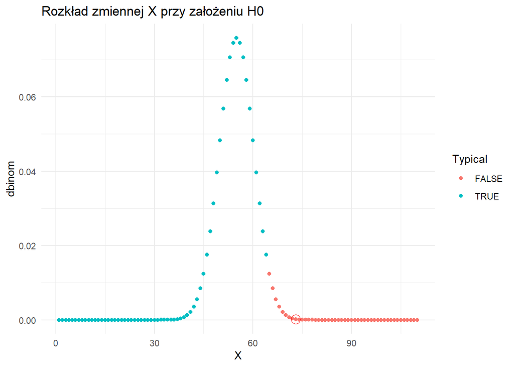

Zad.1.  
H0: Wybór siedliska nie zależy od okresu.  
H1: Wybór siedliska zależy od okresu.  
Przyjmuję poziom istotności róWny 0.05.  
Obliczam tabelę kontyngencji dla zaobserwowanych liczebności.

```
##                     Liczba wystąpień przed 2000 r. Liczba wystąpień po 2000 r.
## skład drewna                                    11                          61
## siedlisko naturalne                             17                          19
```

Następnie obliczam statystykę chi^2 oraz p-value (odpowiednio):

```
## [1] 13.75731
```

```
## [1] 0.0002080098
```

Wartość p-value wskazuje na to, że bardzo nieprawdopodobnym jest otrzymanie takiej próbki, przy założeniu niezależności siedliska i okresu czasu.  
P-value jest mniejsze niż ustalony poziom istotności, więc odrzucam H0 i przyjmuję H1. Wniosek: Wybór siedliska zależy od okresu.

Sprawdzam wyniki przy pomocy chisq.test:

```
##
##  Pearson's Chi-squared test
##
## data:  contingency_table
## X-squared = 12.753, df = 1, p-value = 0.0003555
```

P-value także poniżej poziomu istotności. Nie rozumiem jednak czemu wyszły inne wartości?

```
##
##  C:\Users\LYNX\AppData\Local\Temp\RtmpmwLUpk\downloaded_packages
```

Zad.3.  
H0: Średnie zadłużenie gminy w województwie mazowieckim jest róWne 25%. H1: Średnie zadłużenie gminy w województwie mazowieckim jest mniejsze niż 25%. Przyjmuję poziom istotności równy 0.05. Statystyka T przy założeniu H0 wynosi:

```
## [1] -0.6824053
```

Następnie obliczam p-value:

```
## [1] 0.2477437
```

P-value jest większe niż poziom istotności, więc nie mam podstaw do odrzucenia H0.  
Zatem nie mam podstaw, żeby uznać że średnie zadłużenie jest mniejsze niż 25%.  
Sprawdzam z t.test:

```
##
##  One Sample t-test
##
## data:  mazowieckie$ZadĹ.uĹĽenie.gmin
## t = -0.68241, df = 313, p-value = 0.2477
## alternative hypothesis: true mean is less than 25
## 95 percent confidence interval:
##      -Inf 25.87259
## sample estimates:
## mean of x
##  24.38443
```

Zad.4.  
H0: Wariancja zadłużenia w każdej z tych gmin jest równa 226.  
H1: Wariancja zadłużenia w każdej z tych gmin nie jest równa 226.

Statystyka chi^2 oraz p-value dla zadłużenia gmin w województwie łódzkim wynosi (kolejno):

```
## [1] 176.4413
```

```
## [1] 0.4764612
```

```
## [1] 0.5235388
```

Zatem przy zalozeniu Ho bardzo prawdopodobynm jest otrzymanie takiej próbki. P-value większe od poziomu istotności, więc nie ma podstaw do odrzucenia H0.

Statystyka chi^2 oraz p-value dla zadłużenia gmin w województwie pomorskim wynosi (kolejno):

```
## [1] 121.8292
```

```
## [1] 0.5126699
```

Zatem przy zalozeniu Ho bardzo prawdopodobym jest otrzymanie takiej próbki. P-value większe od poziomu istotności, więc nie ma podstaw do odrzucenia H0.

zad.5.  
H0: Średnie zadłużenie w gminach w obu województwach jest takie samo. H1: Średnie zadłużenie w gminach w obu województwach różni się od siebie. Obliczam statystykę T:

```
## [1] -2.682087
```

P-value wynosi:

```
## [1] 0.003862284
```

P-value mniejsze od poziomu istotności. Odrzucam H0, średnie zadłużenie w gminach w województwach łódzkim i pomorskim są różne.  
Porównuję z t.test:

```
##
##  Two Sample t-test
##
## data:  pomorskie$ZadĹ.uĹĽenie.gmin and lodzkie$ZadĹ.uĹĽenie.gmin
## t = 2.6821, df = 298, p-value = 0.007725
## alternative hypothesis: true difference in means is not equal to 0
## 95 percent confidence interval:
##  1.260811 8.209745
## sample estimates:
## mean of x mean of y
##  28.24544  23.51016
```

Wyniki t-testu potwierdzają moje wnioski.